# Zorizko bektoreak I

Usue Mori

Praktika honetan 2 dimentsiotako zorizko aldagaien dentsitate funtzioak irudikatzen ikasiko dugu.

# Bi aldagaietako funtzio diskretuen irudikapena

$(X,Y)$ zorizko aldagaiak bi txanpon jaurtitzean lortutako emaitza jasotzen du, non $X \in \{A, B\}$ eta $Y \in \{A, B\}$. Bi dimentsiotako aldagai diskretu honen probabilitate masa funtzioa honakoa da:

$$P(X=x, Y=y)= \left\{
\begin{array}{cc}
1/4 , & (x, y) \in \{A, B\} \times \{A, B\}\\
0 , & \mbox{bestela}
\end{array}
\right.$$

Honelako funtzio bat irudikatzeko 3 dimentsiotako barra diagramak erabiliko ditugu, adibidez, eta horretarako, `rgl` eta `barplot3d` paketeak instalatu beharko ditugu (ez badaude iada instalatuta). Lehenengoa CRANen topa dezakegu, beraz instalazioa zuzenean honela egin dezakegu:

```r
install.packages("rgl")
```

Aldiz, `barplot3d` paketea CRANetik ezabatua izan da, mantentze-lanak ez burutzeagatik, baina, pakete honen azken bertsioa CRANeko artxiboan topa dezakegu, honako helbidean: https://cran.r-project.org/src/contrib/Archive/barplot3d/barplot3d_1.0.1.tar.gz. Paketea deskargatu ostean, honela instalatu dezakegu:

```r
#OHARRA: Ziurrenik fitxategiaren helbidea aldatu beharko duzu
install.packages("./barplot3d_1.0.1.tar.gz", repos=NULL, source=TRUE)
```

Orain, funtzioa irudikatuko dugu grafiko interaktibo bat erabiliz:

```r
library(rgl)
library(barplot3d)
probabilities <- rep(1/4, 4)
barplot3d(rows=2, cols = 2, z=probabilities, xlabels = c("A","B"), ylabels= c("A", "B"),
          topcolors="grey")
rglwidget(); close3d()
```

[interactive chart not shown]

$~$

**Ariketa:** Begiratu laguntzan `barplot3d` funtzioaren laguntza eta aldatu parametro batzuk. Nola aldatzen da irudia?

$~$

# Bi aldagaietako funtzio jarraituen irudikapena

Demagun $z = x^2 + y^2$ funtzioa irudikatu nahi dugula, non $x,y \in {\rm I\!R}$. Azken finean, gainazal bat da irudikatu behar duguna. Horrela, lehenik eta behin, zein $x$ eta $y$ balio multzotarako irudikatu nahi dugun zehaztu behar dugu. Adibidez:

```r
x <- seq(-5, 5, length.out=100)
y <- seq(-5, 5, length.out=100)
```

$~$

**Ariketa:** Zein $x$ eta $y$ balio definitzen ditu aurreko kodeak? Nola aldatuko zenuke kodea balioen tarte handiago bat hartzeko? Eta tarte horretan bertan balio gehiago hartzeko?

$~$

Bestetik, $(x, y)$ puntua emanik, dagokion irudia kalkulatuko duen funtzioa definitu behar dugu:

```r
f <- function(x,y) {
  return(x^2 + y^2)
}
```

Ondoren, funtzio honen balioa kalkulatuko dugu aukeratu ditugu $x$ eta $y$ balioen konbinazio posible guztietarako. Horretarako Rko `outer` funtzioa erabiliko dugu, zeinak nahi dugun funtzioa (kasu honetan `f`) aplikatu dien bi bektoreen balioen produktu kartesiarrari (hau da, konbinazio posible guztiei):

```r
z <- outer(X=x, Y=y, FUN=f)
dim(z)
```

```
## [1] 100 100
```

$~$

**Ariketa:** Bistaratu `z` objektua Rn. Zein motako objektua da? Ze informazio jasotzen du eta nola?

$~$

Matrize bat da, z[i][j] f(x[i], y[j]) delarik.

Behin balioak definituta ditunenean, 3 dimentsiotako funtzio bat irudikatzeko modurik errazena Rko `persp` funtzioa erabiltzea da:

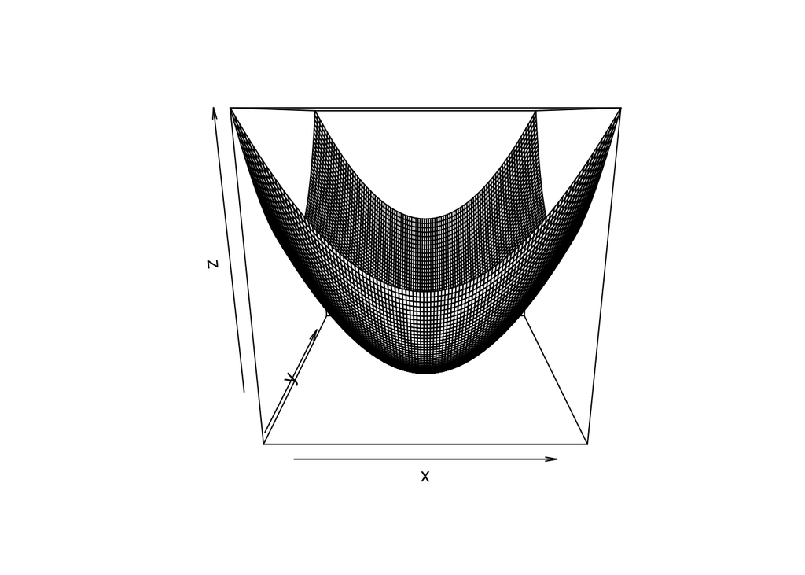

```r
persp(x, y, z)
```

Irudia bira dezakegu norabide bertikalean zein ezker-eskuin, `phi` eta `theta` argumentuekin:

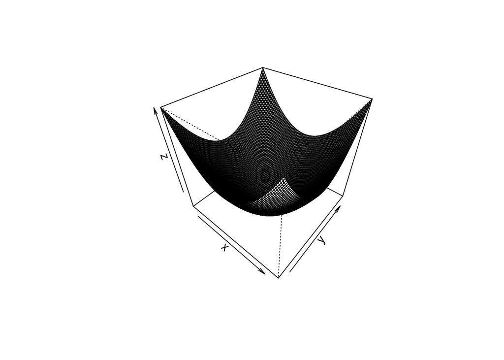

```r
persp(x, y, z, phi=40, theta=40)
```

Irudiaren hainbat ezaugarri (izenburua, kolorea, itzala. . . ) ere gure interesen arabera aldatu ditzakegu:

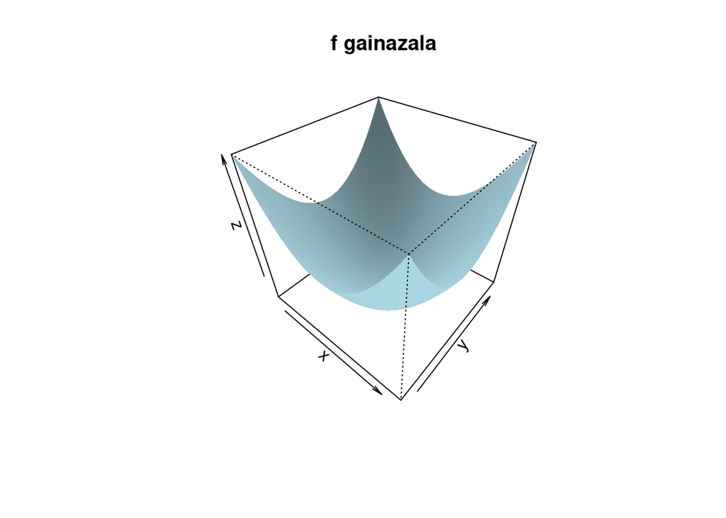

```r
persp(x, y, z, phi=40, theta=40,
      main="f gainazala", col="lightblue", border=NA, shade=0.2)
```

$~$

**Ariketa:** Irudikatu grafiko bera kolorea, izenburua, itzalak, etab. aldatuz.

$~$

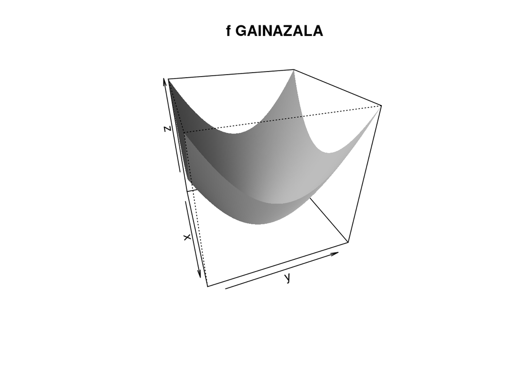

```r
persp(x, y, z, phi=30, theta=70,
      main="f GAINAZALA", col="gray", border=NA, ltheta = -20, lphi = 30, shade=0.7)
```

$~$

**Ariketa:** Grafikoak interaktibo egiteko `rgl` paketeko funtzioak erabili ditzakegu, adibidez `persp3d`. Begiratu laguntzan funtzio hau nola erabiltzen den eta egin $f(x)$ funtzioaren irudikapen interaktiboa.

$~$

```r
persp3d(x, y, z)
rglwidget(); close3d()
```

[interactive chart not shown]

3 dimentsiotako irudiak aztertzea ez da beti erraza, eta batzuetan errazagoa izan daiteke sestra kurbak irudikatzea edo/eta bero-mapak erabiltzea. Lehenengo motako kurbak (sestra-kurbak) Rko `contour` funtzioarekin irudikatu ditzakegu eta bero-mapak, aldiz, `image` funtzioarekin:

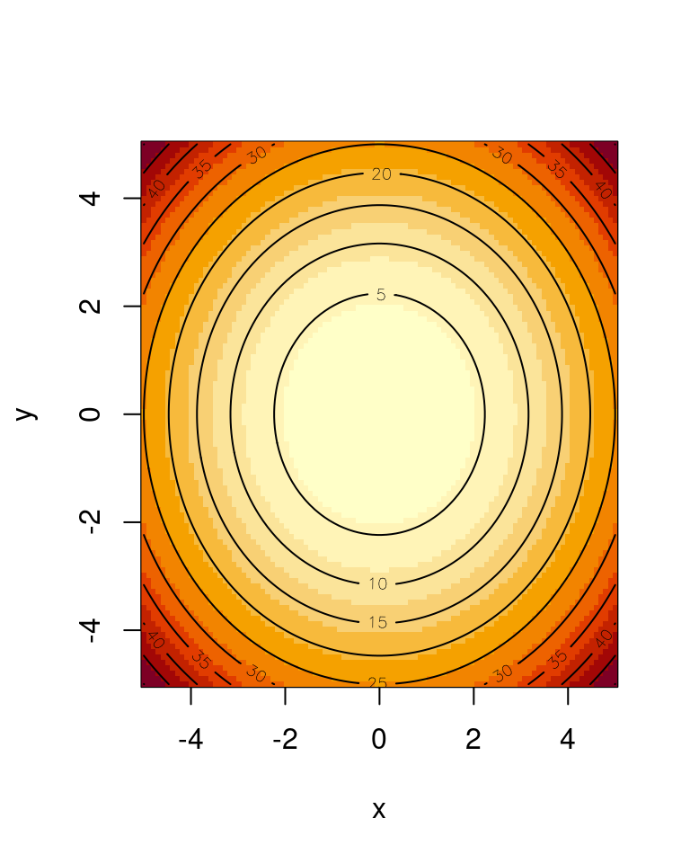

```r
image(x, y, z)
contour(x, y, z, add=TRUE)
```

$~$

**Ariketa:** Rko laguntza erabiliz, aldatu `image` funtzioaren kolore paleta.

$~$

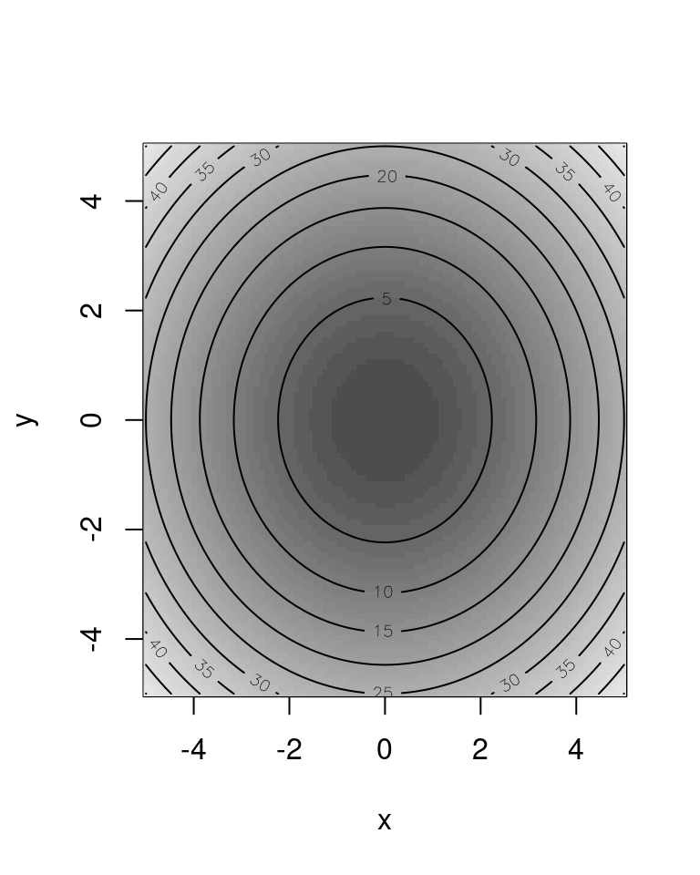

```r
image(x, y, z, col = gray.colors(40))
contour(x, y, z, add=TRUE)
```

# Ariketak

**1. ariketa** Txanpon bat hiru aldiz jaurtitzen dugu. $X$ aldagaiak aurpegi kopurua jasoko du, eta $Y$ aldagaiak aldiz honako arauak dituen jokotik lortutako irabaziak:

1. Jokalariak euro 1 irabaziko du 1. aurpegia 1. jaurtiketan lortzen bada.
2. Jokalariak euro 2 irabaziko du 1. aurpegia 2. jaurtiketan lortzen bada.
3. Jokalariak euro 3 irabaziko du 1. aurpegia 3. jaurtiketan lortzen bada.
4. Jokalariak euro 1 galduko du aurpegirik ez bada ateratzen 3 jaurtiketetan.

Lortu eta irudikatu barra diagrama bat erabiliz $(X,Y)$ aldagaiaren baterako probabilitate-masa funtzioa.

```r
x <- c(0,    1,   2,  3)
y <- c(-1,   1,   2,   3)
z <- c(1/8,  0,   0,   0,
       0,  1/8, 1/8, 1/8,
       0,  2/8, 1/8,   0,
       0,  1/8,   0,   0)

barplot3d(rows=4, cols=4, z=z, ylabels = x, xlabels = y)
rglwidget(); close3d()
```

[interactive chart not shown]

**2. ariketa** Irudika ezazu honako baterako dentsitate funtzio hau (gelako ariketa zerrendako 1.13 ariketakoa):

$$f(x, y)= \left\{
\begin{array}{cc}
xy , & (x, y) \in (0, 2)\times (0, 1)\\
0 , & \mbox{bestela}
\end{array}
\right.$$

```r
x <- seq(0, 2, by = 0.1)
y <- seq(0, 1, by = 0.1)

f <- function(x, y) {return (x*y)}

z <- outer(x, y, f)

persp3d(x, y, z, shade=0.4, ltheta=34, lphi=-10, col="gray")
rglwidget(); close3d()
```

[interactive chart not shown]

Eredu horretatik nolako behaketak lortuko genituzke?

$~$$~$

**3. ariketa** Bi aldagaitako banaketa normala oso banaketa ezaguna da; $(X_1, X_2)' \sim N(\mathbf{\mu}, \mathbf{\Sigma})$ moduan adierazi ohi da, non:

$$\mu = \left(
\begin{array}{c}
E(X_1)\\
E(X_2)
\end{array}
\right) \; \mbox{ eta } \; \Sigma = \left(
\begin{array}{cc}
VAR(X_1) & COV(X_1, X_2)\\
COV(X_1, X_2) & VAR(X_2)
\end{array}
\right)$$
$(X_1, X_2)$-ren baterako dentsitate funtzioa honako hau da:

$$f(\mathbb{x})= \frac{
\exp{\left\{-\frac{1}{2}(\mathbb{x}-\mu)^T\Sigma^{-1}(\mathbb{x}-\mu)\right\}}}{2\pi
\sqrt{|\Sigma|}},$$
non

$$\mathbb{x}=\left(
\begin{array}{c}
x_1\\
x_2
\end{array}\right)$$

1. $\Sigma$ matrizea emanik, nola kalkulatzen da $X_1$ eta $X_2$ren arteko korrelazioa?

$$CORR(X_1, X_2) = \frac{COV(X_1, X_2)}{\sqrt{VAR(X_1)VAR(X_2)}}$$

2. Sortu Rn bi dimentsiotako banaketa normalaren dentsitate funtzioa kalkulatzeko balio duen funtzio bat. Probatu funtzioa $\mu=(0,0)^T$ eta $\Sigma=I_2$ balioetarako.

```r
f <- function(x, Sigma=diag(length(x)), m=rep(0, length(x))){
  k <- length(x)
  det_Sigma <- det(Sigma)
  inv_Sigma <- solve(Sigma)
  coef <- 1 / ((2 * pi)^(k / 2) * sqrt(det_Sigma))
  exp_term <- exp(-0.5 * t(x) %*% inv_Sigma %*% x)
  return(as.numeric(coef * exp_term))
}
```

3. Bilatu bi dimentsiotako banaketa normalaren dentsitate funtzioaren inplementatzen duen Rko berezko paketeren bat.

```r
install.packages("mvtnorm")
```

```r
library(mvtnorm)

eps <- 1e-16
a <- rnorm(2)
dmvnorm(a) - f(a) < eps
```

```
## [1] TRUE
```

4. $Var(X_1)$ eta $Var(X_2)$ balio jakin batzuetarako (aukeratu nahi dituzunak), irudikatu dentsitate funtzioa korrelazio koefiziente balio ezberdinetarako. Erabili zuek sortutako funtzioa eta Rren berezko funtzioa eta konparatu emaitzak.

```r
var1 <- runif(1, 0.3, 3)
var2 <- runif(1, 0.3, 3)
cov <- runif(1, -sqrt(var1*var2), sqrt(var1*var2))
sigma <- matrix(c(var1, cov, cov, var2), 2)

y <- x <- seq(-10, 10, length.out=40)
xy <- expand.grid(x, y)
density <- apply(xy, 1, function(row)f(as.numeric(row), Sigma = sigma))
density2 <- apply(xy, 1, function(row)dmvnorm(as.numeric(row), sigma = sigma))

# f
persp3d(x, y, matrix(density, 40),
      main="Dentstate funtzioa f",
      col="gray",zlab = "Denstitatea",
      border=NA, ltheta = -20, lphi = 30, shade=0.7)
rglwidget(); close3d()
```

[interactive chart not shown]

```r
# dmvnorm
persp3d(x, y, matrix(density2, 40),
      main="Dentstate funtzioa dmvnorm",
      col="gray",zlab = "Denstitatea",
      border=NA, ltheta = -20, lphi = 30, shade=0.7)
rglwidget(); close3d()
```

[interactive chart not shown]

```r
# diferentzia
persp3d(x, y, matrix(density-density2, 40),
      main="Dentstate funtzioen diferentzia",
      col="gray",zlab = "Denstitatea",
      border=NA, ltheta = -20, lphi = 30, shade=0.7)
rglwidget(); close3d()
```

[interactive chart not shown]

**4. problema** Dirichlet banaketa Beta banaketaren orokorpen bat da. $K \ge 2$ ordenako eta $(\alpha_1, \ldots, \alpha_K)$ parametroko ($\alpha_i > 0$) Dirichlet banaketa honelako baterako dentsitate funtzioaren bitartez definitzen da:

$$f(x_1, \ldots, x_K) = \left\{
\begin{array}{cc}
\frac{1}{N}\prod_{i=1}^Kx_i^{\alpha_i-1} & (x_1, \ldots, x_K) \in
(0,1)^K \mbox{ y } \sum_i x_i = 1\\
0 , & \mbox{en otro caso}
\end{array}
\right.$$

Non $N$ normalizazio konstantea den:

$$N=\frac{\prod_{i=1}^K\Gamma(\alpha_i)}{\Gamma(\sum_{i=1}^K
\alpha_i)}$$

```r
dirichlet <- function(x, alpha=rep(1, length(x))) {
  if (any(x <= 0) || abs(sum(x) - 1) > 1e-6) return(0)

  gamma_sum <- gamma(sum(alpha))
  gamma_prod <- prod(gamma(alpha))
  coef <- gamma_sum / gamma_prod # Normalizazioa

  prod_term <- prod(x^(alpha - 1))
  return(coef * prod_term)
}
```

1. Kontsidera ezazu $K=2$ ordenako Dirichlet banaketaren baterako dentsitate funtzioa parametro ezberdinentzako eta irudikatu ezazu $X_1$ balioetarako.

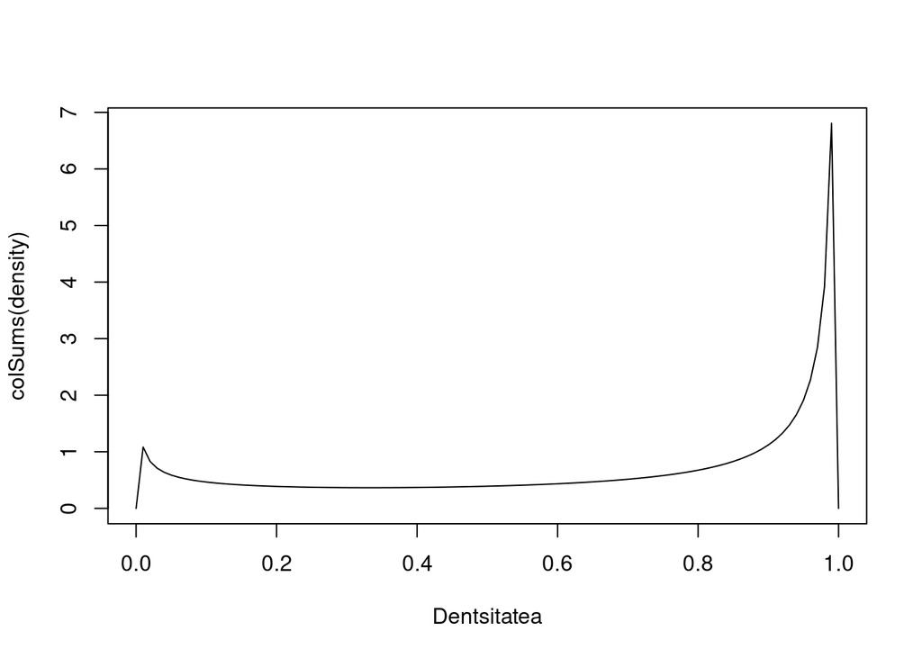

```r
n <- 101
y <- x <- seq(0, 1, length.out = n)
alpha <- c(0.2, 0.6)
xy <- expand.grid(x, y)
density <- apply(xy, 1, function(row)dirichlet(as.numeric(row), alpha = alpha))
density <- matrix(density, n)

plot(x, colSums(density), t="l", xlab = "Dentsitatea")
```

2. Kontsidera ezazu $K=3$ ordenako Dirichlet banaketaren baterako dentsitate funtzioa parametro ezberdinentzako eta irudikatu ezazu $X_1$ eta $X_2$ balioetarako.

```r
n <- 101
y <- x <- seq(0, 1, length.out = n)
alpha <- c(0.9, 0.8, 2)
xy <- expand.grid(x, y)
density <- apply(xy, 1, function(row)dirichlet(as.numeric(c(row, 1-sum(row))), alpha = alpha))
density <- matrix(density, n)

persp3d(x, y, density,
      main="Dentstate funtzioa f",
      col="gray",zlab = "Denstitatea",
      border=NA, ltheta = -20, lphi = 30, shade=0.7)
rglwidget(); close3d()
```

[interactive chart not shown]

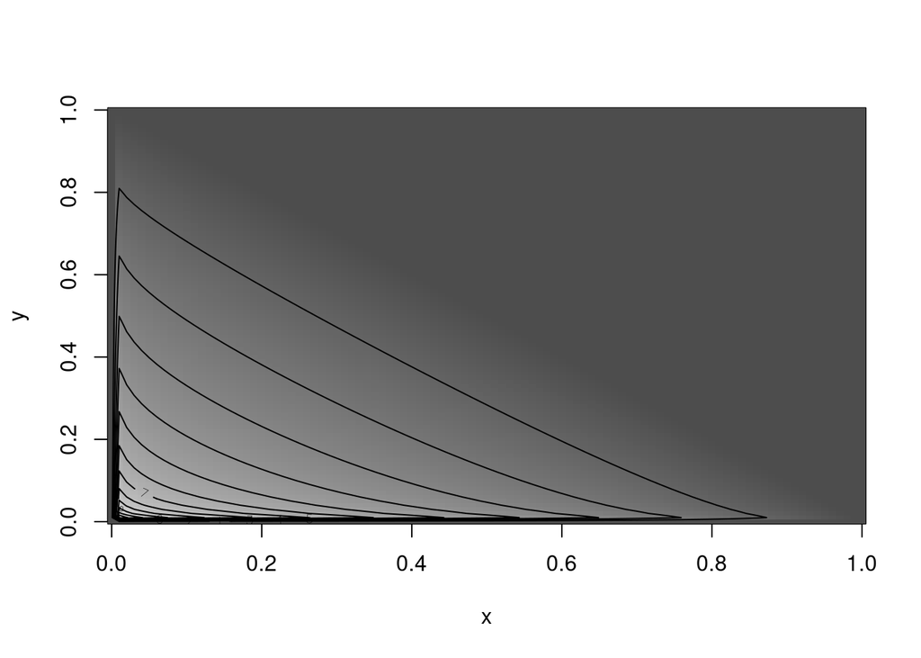

```r
image(x, y, density, col = gray.colors(1000))
contour(x, y, density, add=TRUE)
```

```r
n <- 101
y <- x <- seq(0, 1, length.out = n)
alpha <- c(2, 2, 1)
xy <- expand.grid(x, y)
density <- apply(xy, 1, function(row)dirichlet(as.numeric(c(row, 1-sum(row))), alpha = alpha))
density <- matrix(density, n)

persp3d(x, y, density,
      main="Dentstate funtzioa f",
      col="gray",zlab = "Denstitatea",
      border=NA, ltheta = -20, lphi = 30, shade=0.7)
rglwidget(); close3d()
```

[interactive chart not shown]

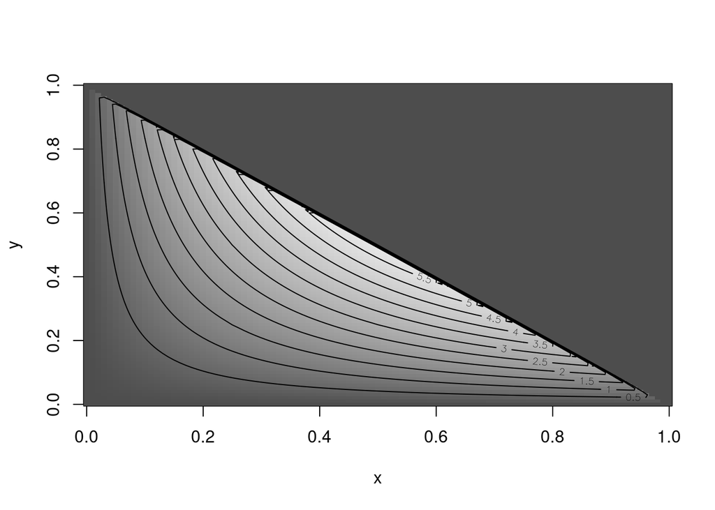

```r
image(x, y, density, col = gray.colors(1000))
contour(x, y, density, add=TRUE)
```

OHARRA: Irudikapenak egiteko, normalizazio konstanteaz ahaztu zaitezkete.